# Séance de travaux dirigés 2 - Deuxième partie

#### Exercice 1

Un jeu nécessite le lancer d’un dé équilibré à 19 faces. Pour jouer à ce jeu, on dispose uniquement d’un dé à six faces que l’on peut lancer un nombre arbitraire de fois. On définit le coût du jeu comme le nombre moyen de lancers du dé à six faces permettant d’obtenir une réalisation de loi uniforme sur l’ensemble $\{1,\dots,19 \}$.

Rappel : [Théorème de la division euclidienne pour les entiers naturels](https://fr.wikipedia.org/wiki/Division_euclidienne). Soit $a$ et $b$ deux entiers naturels tels que $b$ est non nul. Il existe un unique couple d’entiers naturels $(q, r)$ satisfaisant $a = bq + r$ et $r<b$.

##### Question 1

Soit $x$ un entier compris entre 1 et 36. Montrer qu’il existe un unique couple $(q^\star, r^\star) \in \{1,\dots,6\}^2$ satisfaisant
$$x = 6 (q^\star - 1) + r^\star\, .$$
*Indication : Diviser $(x-1)$ par 6*.

##### Question 2

On note $N_1$ et $N_2$ les résultats obtenus suivant deux lancers indépendants du dé à 6 faces.

- Montrer que la variable $X = 6(N_1 - 1) + N_2$ suit la loi uniforme sur l’ensemble $\{1,\dots,36 \}$.
- Proposer une procédure de rejet permettant de simuler le lancer d’un dé à 19 faces à partir du résultat précédent. Déterminer le coût du jeu ?

```r
de.6 <- function(n) sample(1:6, n, replace = T)
de.36 <- function(n) 6*(de.6(n)-1) + de.6(n)
de.19 <- function(n){
  d <- NULL
  for (i in 1:n){
    while ((x <- de.36(1)) > 19){}
    d <- c(x, d)
  }
  return(d)
}
n = 100000

# Temps de calcul
system.time(x.19 <- de.19(n))
```

```
##    user  system elapsed
##  28.852   1.027  29.972
```

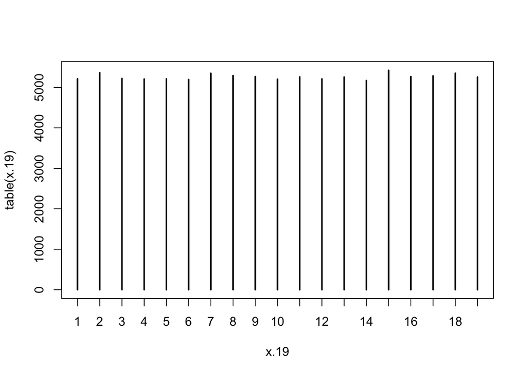

```r
# Histogramme des résultats
plot(table(x.19))
```

##### Question 3

- Proposer des fonctions permettant de simuler le lancer de dés à 4,5,10 ou 20 faces à partir du dé à six faces. Déterminer le nombre moyen de lancers du dé à six faces dans chacune de ces procédures.
- Proposer une procédure de rejet permettant de simuler le lancer d’un dé à 19 faces à partir d’un dé à 20 faces. Quel est le coût du jeu dans la procédure proposée ?
- Peut on trouver une procédure de coût moindre ?